# DATA VISUALIZATION WITH GGPLOT2

Sofía Galván and Miranta Kouvari

2023-08-25

Before starting, an equivalent script using Base R for plotting will be available on the workshop webpage.

### Let’s begin!

1. First, let’s load and prepare the packages and data we are going to work with. In this case, we’ll use the `tetrapods` dataset provided by `palaeoverse` package. Also, we’ll start preparing these data following [Data preparation](https://hackathon.palaeoverse.org/preparation.html) previous tutorial.

```r
library(palaeoverse)
library(ggplot2)
library(svglite)
library(deeptime)
library(extrafont)
data(tetrapods)
?tetrapods

# Assign a common time scale based on an interval key
tetrapods <- look_up(occdf = tetrapods,
                     early_interval = "early_interval",
                     late_interval = "late_interval",
                     int_key = interval_key)

# Making any values which could not be matched contain their original values
tetrapods$interval_max_ma <- ifelse(is.na(tetrapods$interval_max_ma),
                                    tetrapods$max_ma,
                                    tetrapods$interval_max_ma)
tetrapods$interval_min_ma <- ifelse(is.na(tetrapods$interval_min_ma),
                                    tetrapods$min_ma,
                                    tetrapods$interval_min_ma)
tetrapods$interval_mid_ma <- (tetrapods$min_ma + tetrapods$max_ma)/2

#Count number of occurrences per interval
tetrapods_time <- group_apply(occdf = tetrapods, group = "interval_mid_ma", fun = nrow)
tetrapods_time$nrow <- as.numeric(tetrapods_time$nrow)
tetrapods_time$interval_mid_ma <- as.numeric(tetrapods_time$interval_mid_ma)
```

*The general code for plotting with ggplot will be:*

`ggplot(data = my_data, aes(x = my_var1, y = my_var2)) + geom_point()`

2. Now, let’s explore the distribution of one variable through histograms (for continuous variables) and bar plots (for discrete ones).

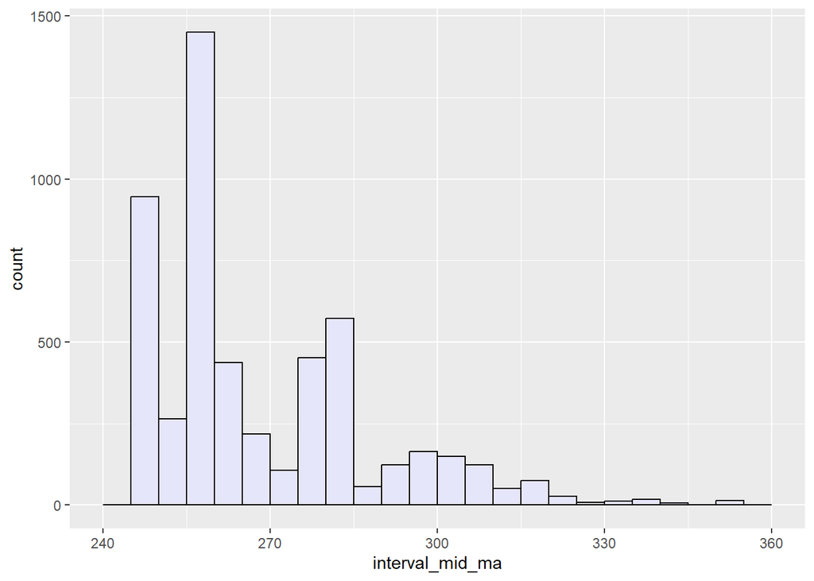

```r
ggplot(data = tetrapods, mapping = aes(x = interval_mid_ma)) +
  geom_histogram(breaks=seq(from = 240, to = 360, by = 5),
                 color="black", fill="lavender")
```

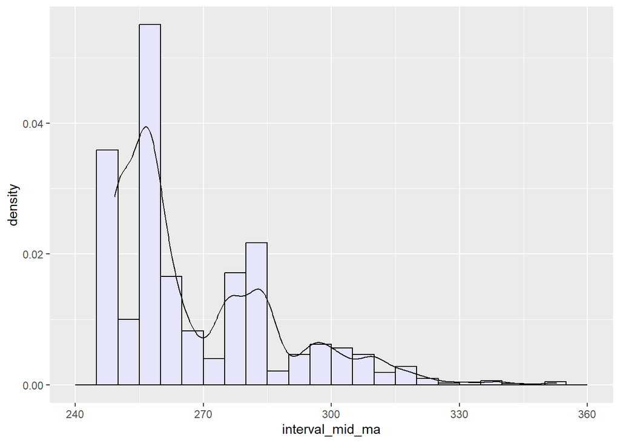

```r
ggplot(data = tetrapods, mapping = aes(x = interval_mid_ma)) +
  geom_histogram(aes(y = after_stat(density)),
                 breaks=seq(from = 240, to = 360, by = 5),
                 color="black", fill="lavender") +
  geom_density() #Adding a density curve
```

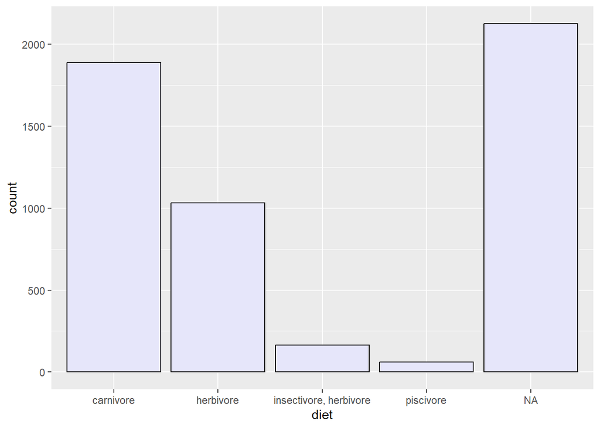

```r
ggplot(data = tetrapods, mapping = aes(x =diet)) +
  geom_bar(color="black", fill="lavender")
```

3. When exploring more than one variable at a time, we can use scatter plots.

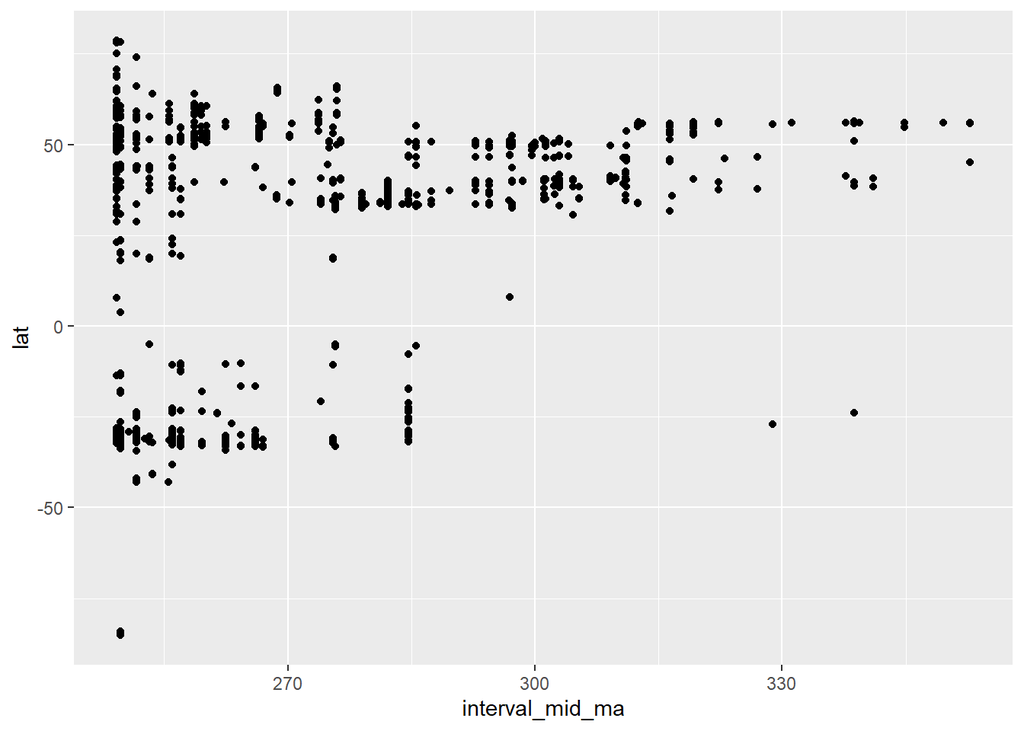

```r
ggplot(data = tetrapods, mapping = aes(x = interval_mid_ma, y = lat)) +
  geom_point() #For a continous variable
```

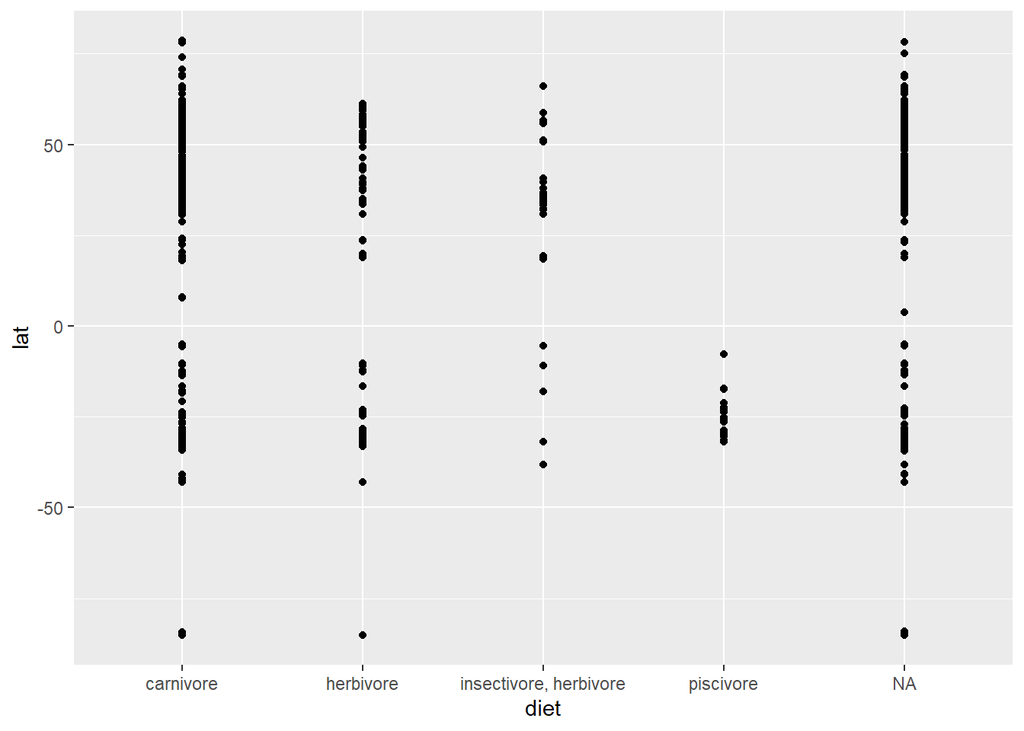

```r
ggplot(data = tetrapods, mapping = aes(x = diet, y = lat)) +
  geom_point() #For a discrete variable
```

We can add other things to the plot, such as a geological axis with the `coor_geo` function of the `deeptime` package:

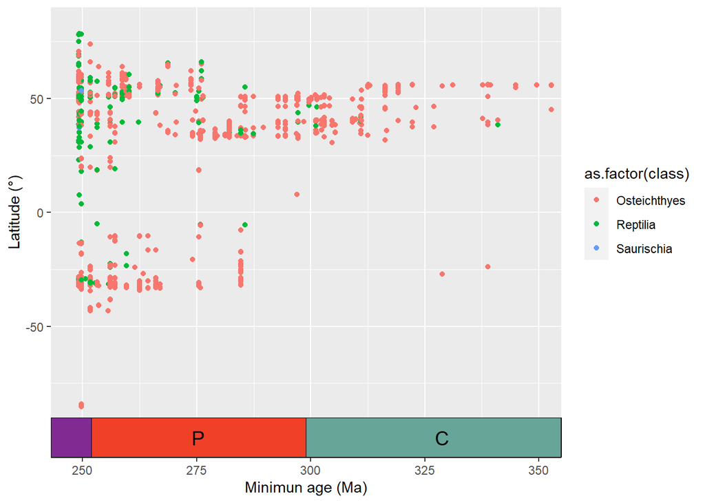

```r
ggplot(data = tetrapods,
       mapping = aes(x = interval_mid_ma, y = lat, color = as.factor(class))) +
  geom_point() +
  xlim(243,355) +
  xlab("Minimun age (Ma)") + ylab("Latitude (\u00B0)") +
  coord_geo(ylim = c(-90,90))
```

And adding more things:

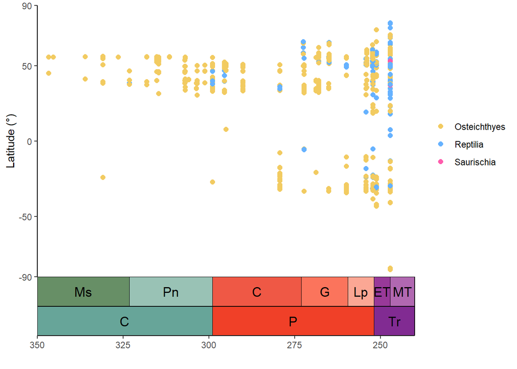

```r
ggplot(data = tetrapods, mapping = aes(x = min_ma, y = lat, color = as.factor(class))) +
  geom_point(size = 2, shape = 16) +
  xlab("") + ylab("Latitude (\u00B0)") +
  xlim(350, 240) +
  scale_y_continuous(limits = c(-90, 90), breaks = c(-90,-50,0,50,90)) +
  scale_color_manual(values = c("#f2cb61", "#66B2FF", "#FF5CAD")) +
  theme_classic() + #Here, we're changing the theme of the plot
  theme(legend.title = element_blank()) + #and removing the legend title
  coord_geo(dat = list("epochs", "periods"), pos = list("b", "b"),
            xlim = c(350, 240), ylim = c(-90,90), size = 4.5,
            center_end_labels = T)
```

4. If we want to compare between groups, box and violin plots are handy.

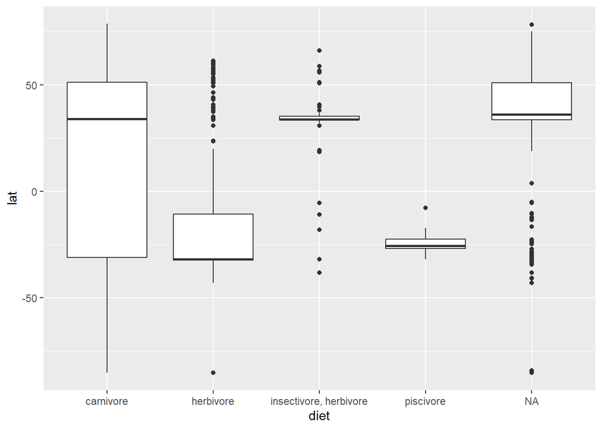

```r
ggplot(data = tetrapods, mapping = aes(x = diet, y = lat)) +
  geom_boxplot()
```

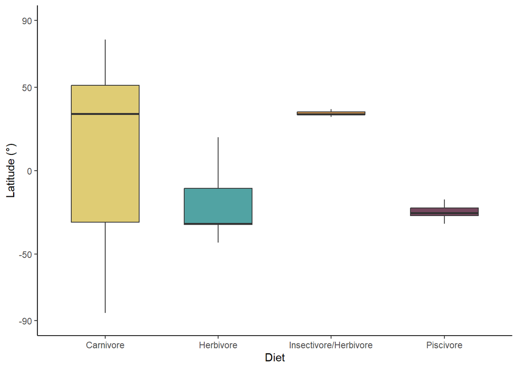

```r
tetrapods <- tetrapods[!is.na(tetrapods$diet),] #Remove entries with no diet information
colcajas <- c("#dfcc74", "#51a3a3", "#cb904d", "#75485e")

#And adding something more:
ggplot(data = tetrapods, mapping = aes(x = diet, y = lat)) +
  geom_boxplot(fill = colcajas, outlier.shape = NA, width = 0.6) +
  xlab("Diet") + ylab("Latitude (\u00B0)") +
  scale_y_continuous(limits = c(-90, 90), breaks = c(-90,-50,0,50,90)) +
  scale_x_discrete(labels = c("Carnivore", "Herbivore", "Insectivore/Herbivore", "Piscivore")) +
  theme_classic()
```

```r
#We will store this plot in a R object.
my_plot <- ggplot(data = tetrapods, mapping = aes(x = diet, y = lat, fill = diet)) +
  geom_violin(scale = "width") +
  geom_boxplot(width=0.06, fill = "white", outlier.shape = NA) + #Adding a boxplot to the violinplot
  xlab("Diet") + ylab("Latitude (\u00B0)") +
  scale_fill_manual(values = colcajas) +
  scale_y_continuous(limits = c(-90, 90), breaks = c(-90,-50,0,50,90)) +
  scale_x_discrete(labels = c("Carnivore", "Herbivore", "Insectivore/Herbivore", "Piscivore")) +
  theme_classic() +
  theme(legend.position="none")
```

5. Lastly, we can save our plots by `ggsave` function, among others.

```r
ggsave(file = "DV_ggplot1.svg", plot = my_plot, device = "svg", scale = 2,
       width = 150, height = 100, units = "mm", dpi = 72, limitsize = TRUE)
```

6. Lastly, we should cite the packages we used, for example:

```r
citation("palaeoverse")
```

```
##
##   Jones, L.A., Gearty, W., Allen, B.J., Eichenseer, K., Dean, C.D.,
##   Galván S., Kouvari, M., Godoy, P.L., Nicholl, C.S.C., Dillon, E.M.,
##   Flannery-Sutherland, J.T., Chiarenza, A.A. 2022. palaeoverse: A
##   community-driven R package to support palaeobiological analysis.
##   Methods in Ecology and Evolution. 00, 1--11. doi:
##   10.1111/2041-210X.14099
##
## A BibTeX entry for LaTeX users is
##
##   @Article{,
##     title = {palaeoverse: A community-driven R package to support palaeobiological analysis},
##     author = {Lewis A. Jones and William Gearty and Bethany J. Allen and Kilian Eichenseer and Christopher D. Dean and Sofía Galván and Miranta Kouvari and Pedro L. Godoy and Cecily S. C. Nicholl and Lucas Buffan and Erin M. Dillon and Joseph T. Flannery-Sutherland and Alfio Alessandro Chiarenza}…
##     year = {2023},
##     journal = {Methods in Ecology and Evolution},
##     pages = {1--11},
##     doi = {10.1111/2041-210X.14099},
##   }
```

## EXTRA!

7. We can change our plot font, using the `extrafont` package to import all the fonts.

```r
font_import()
```

```
## Importing fonts may take a few minutes, depending on the number of fonts and the speed of the system.
## Continue? [y/n]
```

```
## Exiting.
```

```r
fonts()[1:10] #Show the first 10 fonts
```

```
##  [1] "Agency FB"             "Algerian"              "Arial Black"
##  [4] "Arial"                 "Arial Narrow"          "Arial Nova"
##  [7] "Arial Nova Light"      "Arial Nova Cond"       "Arial Nova Cond Light"
## [10] "Arial Rounded MT Bold"
```

8. We also can customize the theme before calling the `ggplot` function. This is useful if we want to apply it to several plots. For more about theme configuration, see `?theme`

```r
Font1 <- "Palatino Linotype"
Size1 <- 13
Size2 <- 11
Map_col <- "#232B2B"
Border_col <- "#FFFFFF"

theme <- theme(
  panel.background = element_blank(),
  plot.margin = margin(0.5, 0.5, 0.5, 0.5, "cm"),
  legend.justification= c(0,1),
  legend.position = c(0.05, 0.85),legend.title = element_blank(),
  legend.background = element_blank(),
  legend.key = element_rect(colour = NA, fill = NA),
  legend.key.size = unit(1.5, "lines"),
  legend.key.width = unit(1.5, "cm"),
  legend.text = element_text(
    size = Size2,
    face = "bold",
    family = Font1),
  panel.border = element_rect(colour = "black", fill = NA),
  axis.text.x = element_text(
    size = Size2,
    angle = 0,
    hjust = 0.5,
    family = Font1),
  axis.text.y = element_text(
    size = Size2,
    angle = 0,
    hjust = 0,
    family = Font1),
  axis.title.y = element_text(
    size = Size1,
    vjust = 5,
    family = Font1),
  axis.title.x = element_text(
    size = Size1,
    vjust = -1,
    family = Font1),
  aspect.ratio = 0.6
  )
```

Let’s apply it to an example plot:

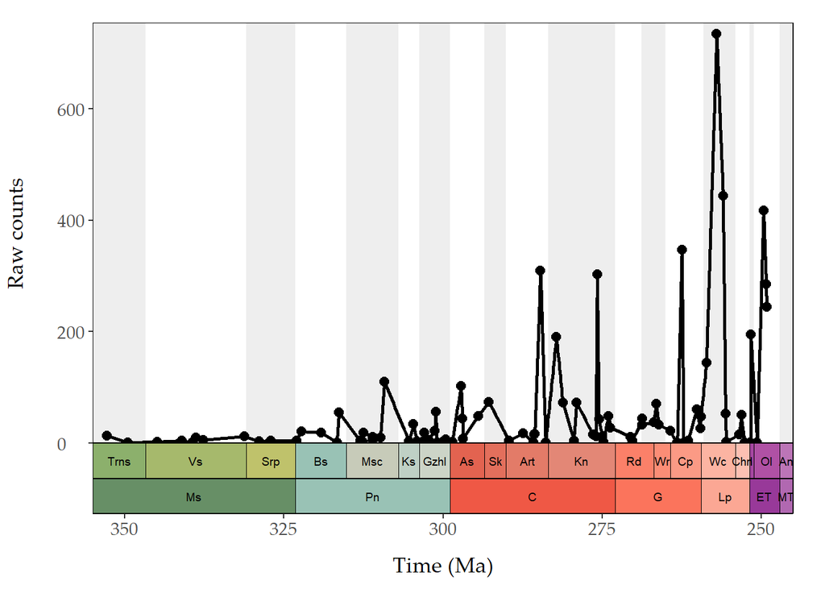

```r
#First, we will prepare the background of the plot.
data(GTS2020)
GTS2020 <- GTS2020[GTS2020$rank == "stage",]
GTS2020 <- GTS2020[GTS2020$min_ma >= 240 & GTS2020$max_ma <= 360,]

seq <- seq(1, 19, 2)
rect <- GTS2020[seq,]

#Then, we plot
ggplot() +
  geom_rect(
    data = rect,
    mapping = aes(
      xmin = min_ma,
      xmax = max_ma,
      ymin = 0,
      ymax = max(tetrapods_time$nrow) + 20
    ),
    linetype = 0,
    color = "grey90",
    alpha = 0.1
  )  +
  geom_line(data = tetrapods_time, aes(
    x = interval_mid_ma,
    y = nrow,
  ), linewidth = 1) +
  geom_point(data = tetrapods_time, aes(
    x = interval_mid_ma,
    y = nrow,
  ), size = 2.5) +
  scale_x_reverse(expand = c(0, 0)) +
  scale_y_continuous(expand = c(0, 0)) +
  labs(x = "Time (Ma)", y = "Raw counts") +
  coord_geo(dat = list("stage", "epochs"), pos = list("b", "b"),
            xlim = c(355, 245), ylim = c(0,max(tetrapods_time$nrow)+20),
            height = unit(1.5, "line"), size = 2.5,
            center_end_labels = T) +
  theme #this is the theme object from above
```

### References

ggplot2: Create Elegant Data Visualisations Using the Grammar of Graphics. https://cran.r-project.org/web/packages/ggplot2/index.html

R for Palaeobiologists: Workshop and Hackathon. https://hackathon.palaeoverse.org/